# **Trabajo Final Bootcamp R - DSRP**

# **PREGUNTA 2: IMPORTAR DATO**

## **1. Importar Datos desde Excel y Ordenar los datos con la función order(), de preferencia para la variable Price_final**

```r
### Importar datos
game <- read.csv("games.csv", sep = ",")

cri_ord <- order(game$price_final)
head(game[cri_ord,])
```

Table continues below

|  | app_id | title | date_release | win | mac |
| --- | --- | --- | --- | --- | --- |
| **27** | 342200 | MechWarrior Online™ Solaris 7 | 2015-12-10 | true | false |
| **93** | 910320 | Three Kingdoms 2019 阿达三国志2019 横版 | 2018-09-18 | true | false |
| **106** | 429300 | Sepia Tears | 2016-01-08 | true | true |
| **137** | 367120 | Seduce Me the Otome | 2015-06-04 | true | true |
| **173** | 755790 | Ring of Elysium | 2019-06-24 | true | false |
| **175** | 758980 | Poker Legends: Texas Hold’em Poker Tournaments | 2018-04-04 | true | true |

Table continues below

|  | linux | rating | positive_ratio | user_reviews |
| --- | --- | --- | --- | --- |
| **27** | false | Mostly Positive | 79 | 10219 |
| **93** | false | Mostly Positive | 76 | 326 |
| **106** | true | Very Positive | 88 | 886 |
| **137** | true | Very Positive | 86 | 2149 |
| **173** | false | Mostly Positive | 74 | 100444 |
| **175** | false | Mostly Positive | 76 | 591 |

|  | price_final | price_original | discount | steam_deck |
| --- | --- | --- | --- | --- |
| **27** | 0 | 0 | 0 | true |
| **93** | 0 | 0 | 0 | true |
| **106** | 0 | 0 | 0 | true |
| **137** | 0 | 0 | 0 | true |
| **173** | 0 | 0 | 0 | true |
| **175** | 0 | 0 | 0 | true |

## **2. Mostrar el dataframe ordenado de manera ascendente y descendente orden de manera ascendente**

**Datos en Orden ascendente**

```r
# ascendente
cri_ord <- order(game$price_final)
head(game[cri_ord,])
```

Table continues below

|  | app_id | title | date_release | win | mac |
| --- | --- | --- | --- | --- | --- |
| **27** | 342200 | MechWarrior Online™ Solaris 7 | 2015-12-10 | true | false |
| **93** | 910320 | Three Kingdoms 2019 阿达三国志2019 横版 | 2018-09-18 | true | false |
| **106** | 429300 | Sepia Tears | 2016-01-08 | true | true |
| **137** | 367120 | Seduce Me the Otome | 2015-06-04 | true | true |
| **173** | 755790 | Ring of Elysium | 2019-06-24 | true | false |
| **175** | 758980 | Poker Legends: Texas Hold’em Poker Tournaments | 2018-04-04 | true | true |

Table continues below

|  | linux | rating | positive_ratio | user_reviews |
| --- | --- | --- | --- | --- |
| **27** | false | Mostly Positive | 79 | 10219 |
| **93** | false | Mostly Positive | 76 | 326 |
| **106** | true | Very Positive | 88 | 886 |
| **137** | true | Very Positive | 86 | 2149 |
| **173** | false | Mostly Positive | 74 | 100444 |
| **175** | false | Mostly Positive | 76 | 591 |

|  | price_final | price_original | discount | steam_deck |
| --- | --- | --- | --- | --- |
| **27** | 0 | 0 | 0 | true |
| **93** | 0 | 0 | 0 | true |
| **106** | 0 | 0 | 0 | true |
| **137** | 0 | 0 | 0 | true |
| **173** | 0 | 0 | 0 | true |
| **175** | 0 | 0 | 0 | true |

**Datos en Orden descendente**

```r
# descendente
cri_ord <- order(-game$price_final)
head(game[cri_ord,])
```

Table continues below

|  | app_id | title | date_release | win |
| --- | --- | --- | --- | --- |
| **5449** | 267810 | Clickteam Fusion 2.5 Developer Upgrade | 2014-01-27 | true |
| **23389** | 253670 | Aartform Curvy 3D 3.0 | 2013-11-12 | true |
| **21062** | 502570 | Houdini Indie | 2018-10-10 | true |
| **91** | 438450 | 3DF Zephyr Lite Steam Edition | 2016-02-02 | true |
| **13994** | 2235780 | Hidden Post-Apocalyptic 3 Top-Down 3D | 2022-12-17 | true |
| **14087** | 2278120 | Break Everything - Park | 2023-01-27 | true |

Table continues below

|  | mac | linux | rating | positive_ratio | user_reviews |
| --- | --- | --- | --- | --- | --- |
| **5449** | false | false | Positive | 100 | 22 |
| **23389** | false | false | Mixed | 69 | 39 |
| **21062** | true | false | Very Positive | 94 | 148 |
| **91** | false | false | Very Positive | 96 | 58 |
| **13994** | true | true | Mostly Positive | 75 | 16 |
| **14087** | false | false | Positive | 100 | 11 |

|  | price_final | price_original | discount | steam_deck |
| --- | --- | --- | --- | --- |
| **5449** | 300 | 300 | 0 | true |
| **23389** | 299.9 | 299.9 | 0 | true |
| **21062** | 270 | 270 | 0 | true |
| **91** | 200 | 200 | 0 | true |
| **13994** | 200 | 200 | 0 | true |
| **14087** | 200 | 200 | 0 | true |

## **3. Calcular el resumen estadístico de los datos con la función que corresponde**

```r
# resumen
summary(game)
```

```
##      app_id           title           date_release           win
##  Min.   :     10   Length:46068       Length:46068       Length:46068
##  1st Qu.: 501723   Class :character   Class :character   Class :character
##  Median : 916285   Mode  :character   Mode  :character   Mode  :character
##  Mean   : 986443
##  3rd Qu.:1422158
##  Max.   :2319990
##      mac               linux              rating          positive_ratio
##  Length:46068       Length:46068       Length:46068       Min.   :  0.00
##  Class :character   Class :character   Class :character   1st Qu.: 66.00
##  Mode  :character   Mode  :character   Mode  :character   Median : 81.00
##                                                           Mean   : 76.76
##                                                           3rd Qu.: 91.00
##                                                           Max.   :100.00
##   user_reviews      price_final      price_original       discount
##  Min.   :     10   Min.   :  0.000   Min.   :  0.000   Min.   : 0.000
##  1st Qu.:     20   1st Qu.:  1.383   1st Qu.:  1.990   1st Qu.: 0.000
##  Median :     53   Median :  4.990   Median :  5.990   Median : 0.000
##  Mean   :   1843   Mean   :  8.751   Mean   :  9.299   Mean   : 5.185
##  3rd Qu.:    226   3rd Qu.: 11.990   3rd Qu.: 12.990   3rd Qu.: 0.000
##  Max.   :6941137   Max.   :299.990   Max.   :299.990   Max.   :90.000
##   steam_deck
##  Length:46068
##  Class :character
##  Mode  :character
##
##
##
```

## **4. Realizar las graficas**

**Distribucion del precio final por compatibilidad con windowns**

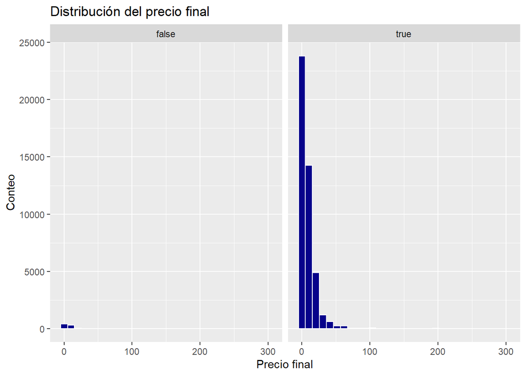

```r
#
ggplot(game, aes(x = price_final)) +
  geom_histogram(color = "white", fill = "#07038B") +
  labs(title = "Distribución del precio final",
       x = "Precio final",
       y = "Conteo") +
  facet_grid(~win)
```

**Distribucion del precio final por compatibilidad con linux**

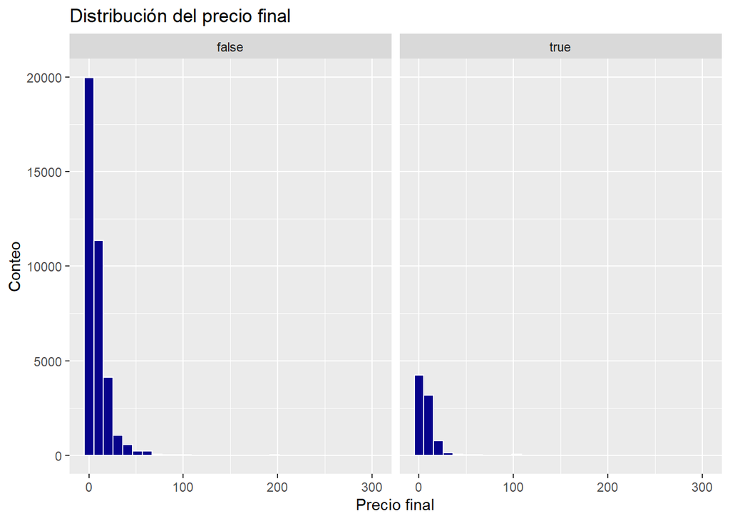

```r
# d
ggplot(game, aes(x = price_final)) +
  geom_histogram(color = "white", fill = "#07038B") +
  labs(title = "Distribución del precio final",
       x = "Precio final",
       y = "Conteo") +
  facet_grid(~linux)
```

**Gráfico de barras Rating**

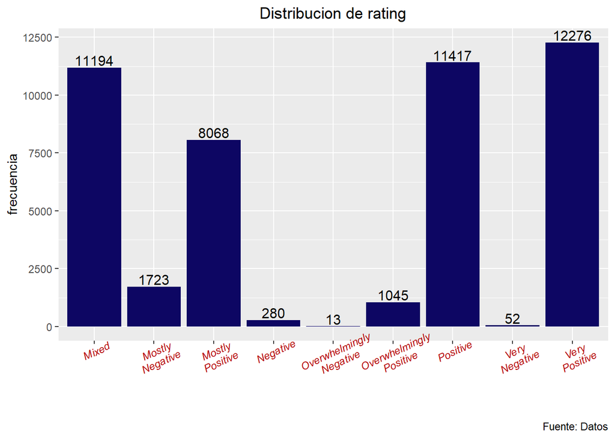

```r
ggplot(game, aes(x = rating)) +
  geom_bar(fill = "#0D0663") +
  scale_x_discrete(labels = function(x) str_wrap(x, width = 10)) +
  labs(caption = "Fuente: Datos",
       x = " ",
       y = "frecuencia") +
  theme(axis.text.x = element_text(angle = 25, face = "italic", colour = "#B50202"))+
  ggtitle("Distribucion de rating") +
  theme(plot.title = element_text(hjust = 0.5, vjust = 1)) +
  geom_text(aes(label = ..count..), stat='count',
            position = position_dodge(0.9),
            vjust = -0.2,
            size = 4.0)
```

**Distribucion del precio final**

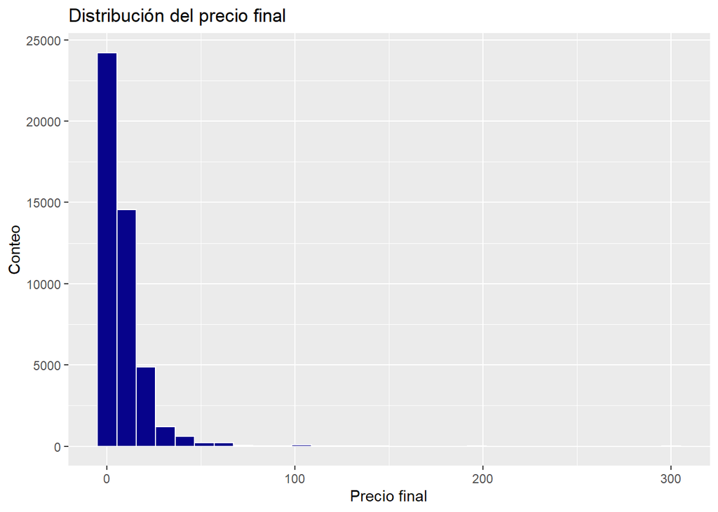

```r
ggplot(game, aes(x = price_final)) +
  geom_histogram(color = "white", fill = "#07038B") +
  labs(title = "Distribución del precio final",
       x = "Precio final",
       y = "Conteo")
```

**Distribucion del precio original**

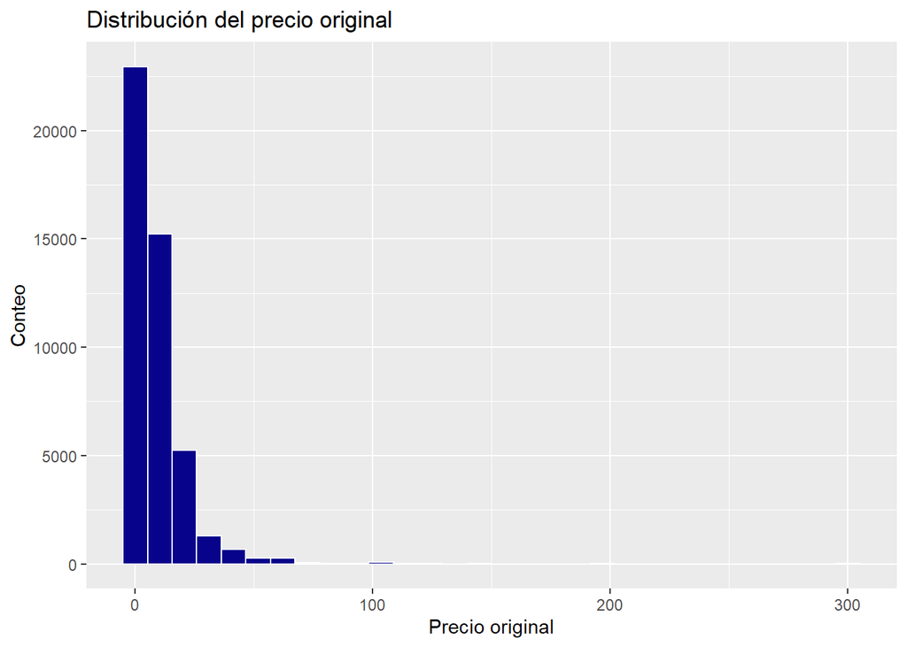

```r
#
ggplot(game, aes(x = price_original)) +
  geom_histogram(color = "white", fill = "#07038B") +
  labs(title = "Distribución del precio original",
       x = "Precio original",
       y = "Conteo")
```

```r
  #ylim(c(0,25000))
```

**Gráfico de dispersión de precio final vs Relación positiva**

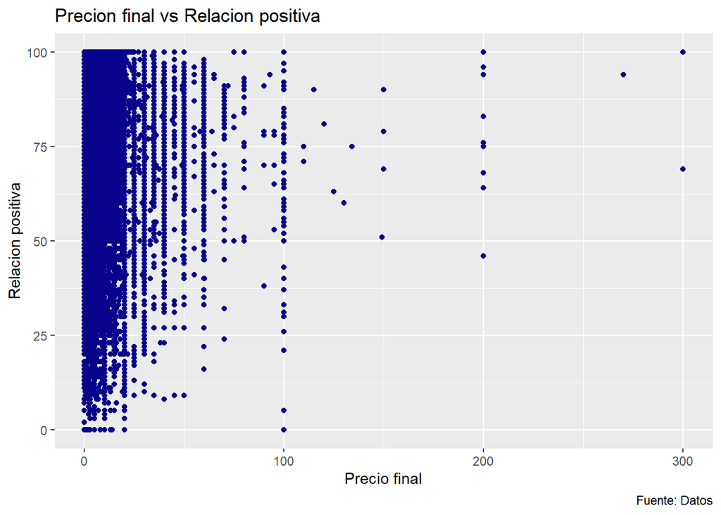

```r
#
ggplot(game, aes(x = price_final, y = positive_ratio)) +
  geom_point(color = "#07038B") +
  labs(title = "Precion final vs Relacion positiva",
       caption = "Fuente: Datos",
       x = "Precio final",
       y = "Relacion positiva")
```

**Gráfico de caja de Relacion positiva**

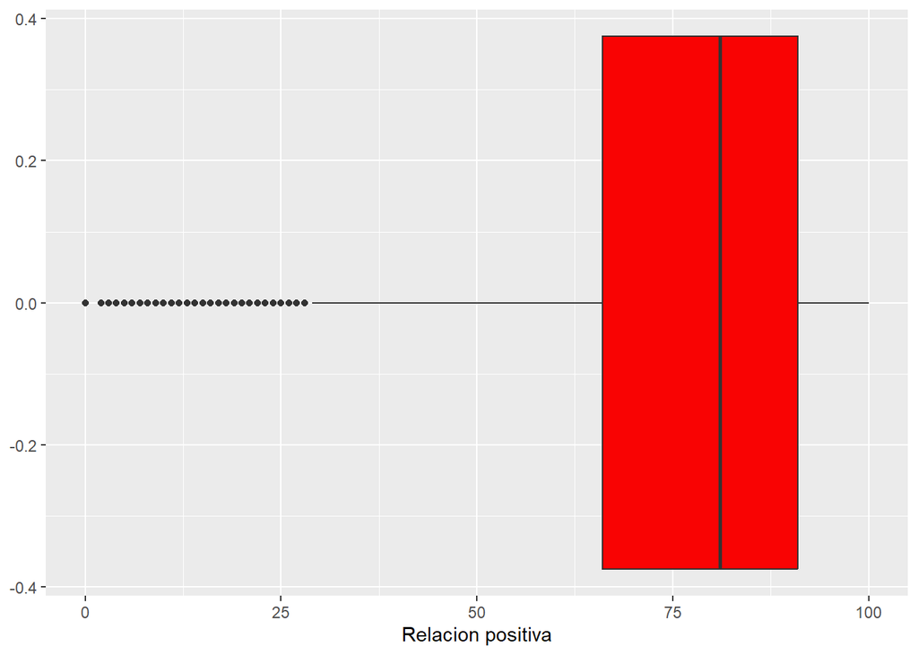

```r
# g
ggplot(game, aes(x = positive_ratio)) +
  geom_boxplot(fill = "#F90303") +
  labs(x = "Relacion positiva")
```

# **PREGUNTA 3: PROGRAMACION**

## **1. Implementar una función para la multiplicación de dos vectores(xy) y probar con valores**

```r
# funcion
multiplicacion <- function(x,y){
  resultado <- x*y
  return(resultado)
}
```

Ejecutando funcion

```r
x1 <- c(5,7,4)
x2 <- c(2,7,5)

multiplicacion(x1,x2)
```

```
## [1] 10 49 20
```

## **2. Implementar una función que muestre el resultado de la ecuación de Bhaskara y probar con valores.**

Creamos la funcion `ecu_Bhaskara` que nos devuelva las soluciones para la ecuación y ademas realice una grafica.

```r
# ecuación de Bhaskara
ecu_Bhaskara <- function(a,b,c){
  ecuación <- paste0(a,'*x^2 + ', b,'*x + ', c, collapse = ",")
  #print(paste0('Resolviendo la ecuacion: ', a,'*x^2 + ', b,'*x +', c, collapse = ", "))
  print(paste0('Resolviendo la ecuacion: ', ecuación, collapse = ", "))

  discriminante <- (b^2-4*a*c)

  if (discriminante < 0) {
    print("¡No existen soluciones Reales a la ecuación!")
    x1 = (-b + sqrt(as.complex(b^2 - 4*a*c)))/(2*a)
    x2 = (-b - sqrt(as.complex(b^2 - 4*a*c)))/(2*a)
    }
  else {
    x1 = (-b + sqrt(discriminante))/(2*a)
    x2 = (-b - sqrt(discriminante))/(2*a)
    }
  cat(rep("-----",10),'\n')
  print('Las soluciones de la ecuación:')
  print(paste0('La solucion x1 es: ', x1, ' y de x2 es: ' , x2,
               collapse = ','))
  #Grafica de la ecuación
  cat(rep("-----",10),"\nGrafica de la ecuacion: (", ecuación, ") -> v ")
  curve(a*x^2 + b*x + c, xlim = c(-20,20), ylim = c(-10, 120),
        col = "red", lwd=3.5)
  abline(h=0, v=0, col="blue", lwd=2.5)
}
```

Ejecutando función con ejemplos

```r
ecu_Bhaskara(1,4,2)
```

```
## [1] "Resolviendo la ecuacion: 1*x^2 + 4*x + 2"
## ----- ----- ----- ----- ----- ----- ----- ----- ----- -----
## [1] "Las soluciones de la ecuación:"
## [1] "La solucion x1 es: -0.585786437626905 y de x2 es: -3.41421356237309"
## ----- ----- ----- ----- ----- ----- ----- ----- ----- -----
## Grafica de la ecuacion: ( 1*x^2 + 4*x + 2 ) -> v
```

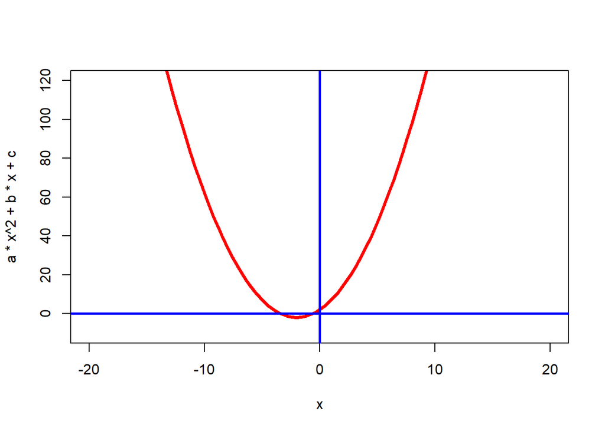

```r
ecu_Bhaskara(1, -5, 4)
```

```
## [1] "Resolviendo la ecuacion: 1*x^2 + -5*x + 4"
## ----- ----- ----- ----- ----- ----- ----- ----- ----- -----
## [1] "Las soluciones de la ecuación:"
## [1] "La solucion x1 es: 4 y de x2 es: 1"
## ----- ----- ----- ----- ----- ----- ----- ----- ----- -----
## Grafica de la ecuacion: ( 1*x^2 + -5*x + 4 ) -> v
```

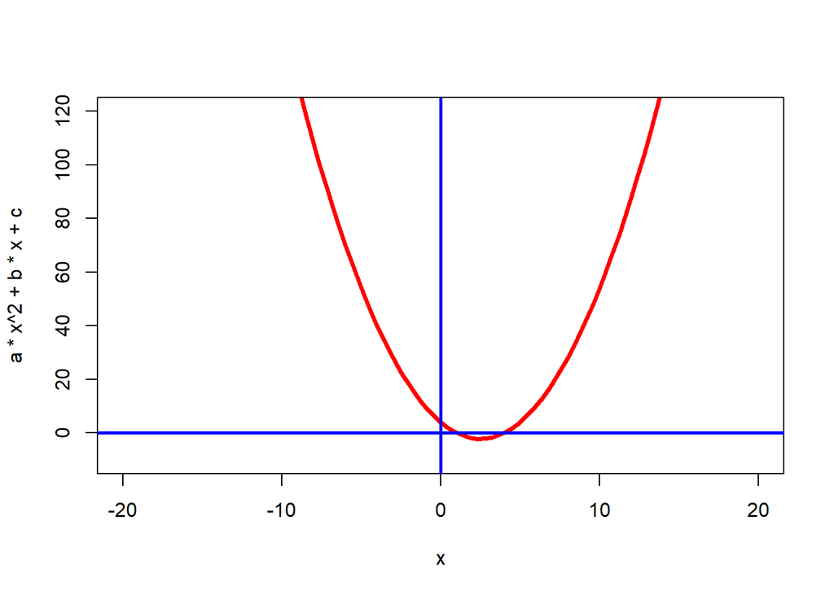

```r
ecu_Bhaskara(2, -6, 5)
```

```
## [1] "Resolviendo la ecuacion: 2*x^2 + -6*x + 5"
## [1] "¡No existen soluciones Reales a la ecuación!"
## ----- ----- ----- ----- ----- ----- ----- ----- ----- -----
## [1] "Las soluciones de la ecuación:"
## [1] "La solucion x1 es: 1.5+0.5i y de x2 es: 1.5-0.5i"
## ----- ----- ----- ----- ----- ----- ----- ----- ----- -----
## Grafica de la ecuacion: ( 2*x^2 + -6*x + 5 ) -> v
```

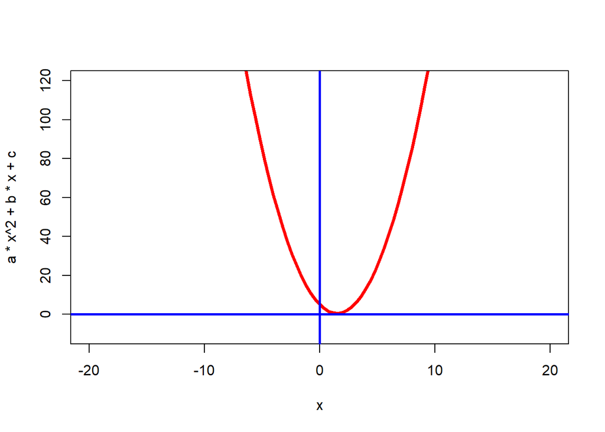

## **3. Se quiere conocer la media muestral de n observaciones obtenidas independientemente de una distribución normal con media = 0 y varianza = 1.**

**3.1. Realizar una simulación, luego calcular las estadísticas descriptivas aplicando la función que corresponde y graficar.**

**Simulando datos normales:**

```r
# simulando
set.seed(2023)
observaciones <- rnorm(1000,0,1)
head(observaciones)
```

```
## [1] -0.08378436 -0.98294375 -1.87506732 -0.18614466 -0.63348570  1.09079746
```

**Calculando las estadísticas descriptivas:**

```r
summary(observaciones)
```

```
##     Min.  1st Qu.   Median     Mean  3rd Qu.     Max.
## -3.24594 -0.72756 -0.04653 -0.02398  0.66192  4.57432
```

**Graficamos: histograma y densidad de las observaciones**

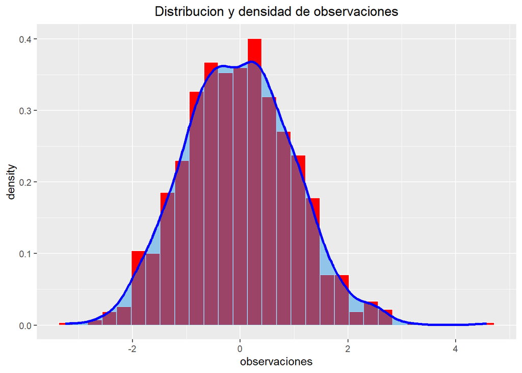

```r
# histograma y densidad de las observaciones
ggplot(data.frame(observaciones), aes(observaciones))+
  geom_histogram(aes(y = ..density..),
                 colour = "white", fill = "red") +
  geom_density(lwd = 1.2, colour = "blue",
               fill = 4, alpha = 0.45) +
  ggtitle("Distribucion y densidad de observaciones") +
  theme(plot.title = element_text(hjust = 0.5, vjust = 1))
```

**Graficamos: caja y bigotes**

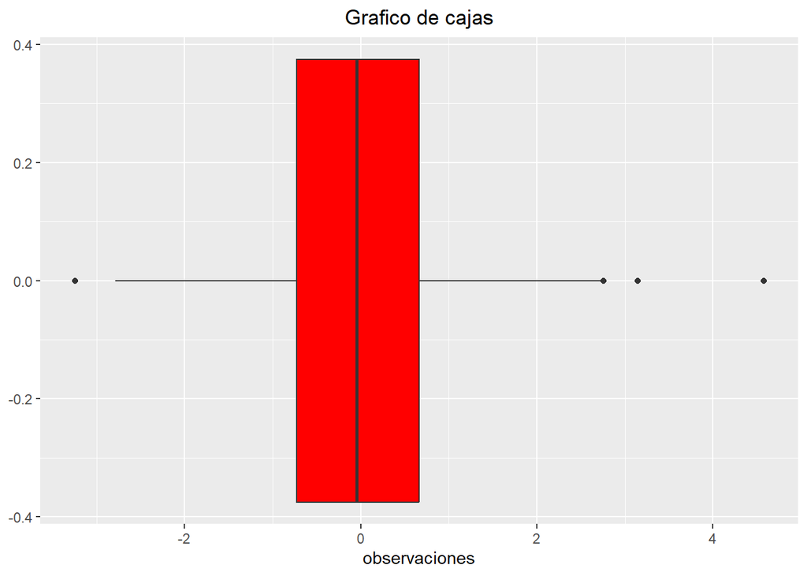

```r
# grafico de caja  y bigotes
ggplot(data.frame(observaciones), aes(x = observaciones)) +
  geom_boxplot(fill = "red1") +
  ggtitle("Grafico de cajas") +
  theme(plot.title = element_text(hjust = 0.5, vjust = 1))
```